# BIOLM0039_Programming-in-R_kv22535

2228819

2023-08-06

## Read in the data

The provided data sets is read into the project by using “vroom package” to read the data from the file path.

However, the data were not in a data frame, hence the use of “col_type” argument to specify the variables to the right column. The argument takes the cols() method and each parameter is set to the correct data type.

```r
#Read the NAO data
NAO_data1 <- vroom("C:\\Users\\kv22535\\Downloads\\NAO_kv22535-1.tsv.gz", delim = "\t",
                     col_types = cols(
                     month = col_character(),
                     year = col_double(),
                     NAO = col_double()
                   ))
mass_data1 <- vroom("C:\\Users\\kv22535\\Downloads\\mass_kv22535-1.tsv.gz", delim = "\t",
                     col_types = cols(
                     year = col_double(),
                     ID = col_double(),
                     age = col_double(),
                     sex = col_character(),
                     n_babies = col_double(),
                     observer = col_double(),
                     pop_size = col_double(),
                     weight = col_double()
                   ))

# Print the column specification
View(NAO_data1)
View(mass_data1)
```

## Data tiding

### NAO data

The NAO data is represented by three (3) columns, each represent: year, month and NAO.

### Mass data

The mass data frame contain eight(8) columns. However, the “weight” column contains some invalid data (NA), to remove this, the filter() function is used to remove the “NA” values specifically from the “weight” column.

### Merging the NAO and Mass data

To enhance the analysis and give better context to the data set, the NAO and mass data frame are merged together using the merge() method. The common value used for merging is “year”.

```r
# Filter out NA values from NA weight column
filtered_massdata <- mass_data1 %>% filter(!is.na(weight))
View(filtered_massdata)

#Merge by year
merged_data <- merge(filtered_massdata, NAO_data1, by = "year")
View(merged_data)
```

## Data visualization

To analyse the data in relation to the weight, a geom_boxplot() is used for visualization. The ggplot() function sets up the base plot with the merged_data as the data source and defines the aesthetics (aes) mapping for the plot. From the visualization, the line inside the box represents the median weight, data points beyond the whiskers are considered potential outliers and are plotted as individual points.

### 1. n_babies & sex/weight

By comparing the boxplots for different categories of n_babies with corresponding colors for male and female, it is observed that the weight of female Soay Sheep is higher than male sheep.

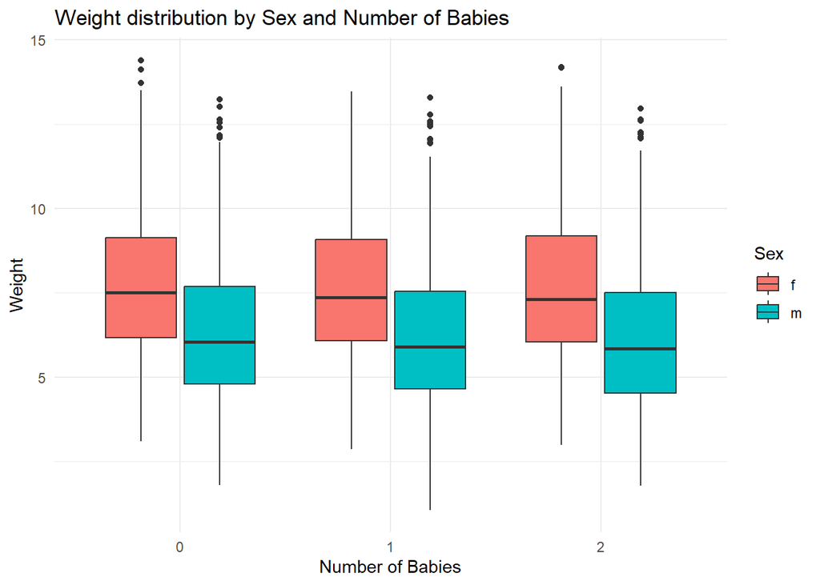

n_babies against weight.

```r
ggplot(merged_data, aes(x = factor(n_babies), y = weight, fill = sex)) +
  geom_boxplot() +
  labs(title = "Weight distribution by Sex and Number of Babies",
       x = "Number of Babies",
       y = "Weight") +
  #theme_minimal(): Reduces background elements and gridlines to keep the focus on the data.
#scale_fill_discrete(): It sets the legend title to "sex" to indicate that the colors in the plot represent different sex(male , female)).
  scale_fill_discrete(name = "Sex") +
  theme_minimal()
```

### 2. age/weight

By comparing the boxplots for different age categories, It is observed each box appears progressively higher as the age increases, this indicates that the weight is higher in consecutive age category, showing clear variance.

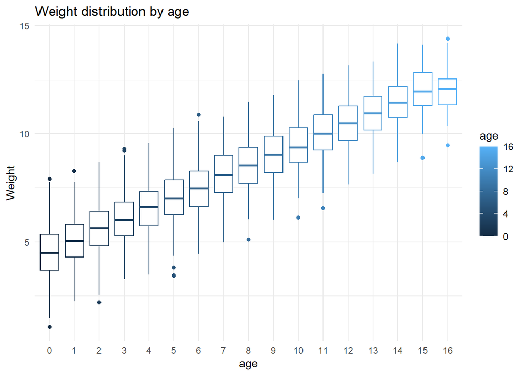

age against weight.

```r
#theme_minimal(): Reduces background elements and gridlines to keep the focus on the data.
#scale_fill_discrete(): It sets the legend title to "age" to indicate that the colors in the plot represent different age grade).

ggplot(merged_data, aes(x = factor(age), y = weight, color = age)) +
  geom_boxplot() +
  labs(title = "Weight distribution by age",
       x = "age",
       y = "Weight") +
  scale_fill_discrete(name = "age") +
  theme_minimal()
```

### 3. NAO/weight

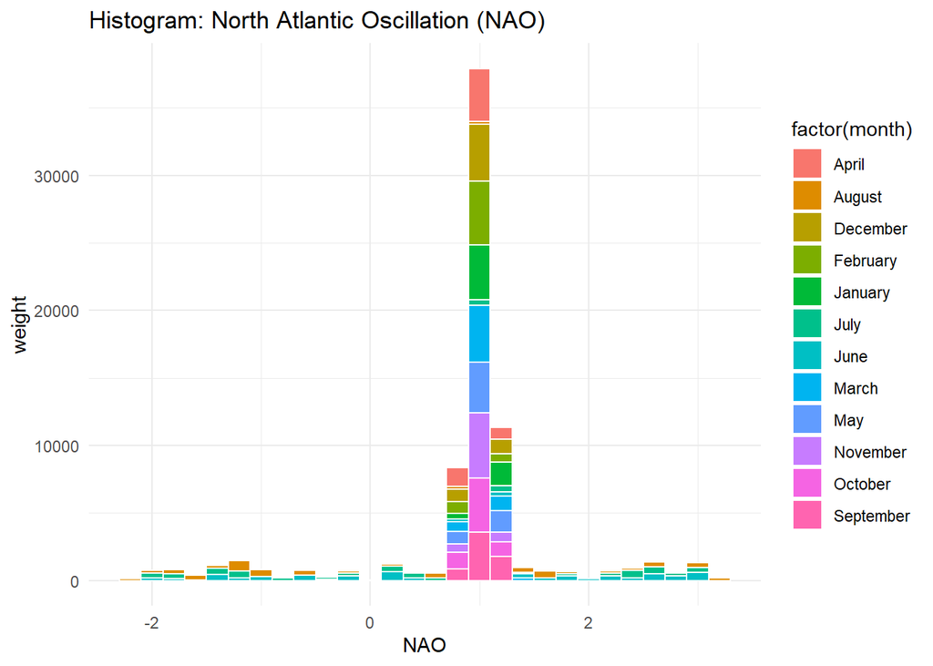

```r
#geom_histogram() is used to create the histogram and set the bin width to 0.2 to control the width of the bins.
#theme_minimal(): Reduces background elements and gridlines to keep the focus on the data.

ggplot(merged_data, aes(x = NAO, fill = factor(month))) +
  geom_histogram(binwidth = 0.2, color = "white")  +
  labs(title = "Histogram: North Atlantic Oscillation (NAO)",
       x = "NAO",
       y = "weight") +
  theme_minimal()
```

## Generalized linear model(GLM)

```r
#The response variable from the analysis is "weight". While we have visualized "NAO", "Sex", "n_babies" and "age" as a predictor variable.
```

A statistic modelling is performed to establish strength and clear relationship that exist between the predictor variable and response variables.

In this project, GLM is selected for statistical modeling because it is best to capture continuous response variable such as “weight”. Also, it is good for checking linear relationship between variables. Since the response variable is continuous, the “Gaussian” distribution is used for this model.

### Model 1

This model shows that each one-unit increase in age, the weight of Soay sheep increases by approximately 0.492 units. The low residual deviance (93770: lower than the null deviance) and AIC (229100) suggest that the model fits the data relatively well, and the age variable has a significant effect on the weight of the sheep.

```r
mod1_1 <- glm(weight ~ age,
            ##specify the data
            data = merged_data,
            ##specify the error structure
            family = "gaussian")
mod1_1
```

```
##
## Call:  glm(formula = weight ~ age, family = "gaussian", data = merged_data)
##
## Coefficients:
## (Intercept)          age
##       4.577        0.492
##
## Degrees of Freedom: 74771 Total (i.e. Null);  74770 Residual
## Null Deviance:       376200
## Residual Deviance: 93770     AIC: 229100
```

### Model 2

```r
mod2_2 <- glm(weight ~ NAO,
              data = merged_data,
              family = "gaussian")

mod2_2
```

```
##
## Call:  glm(formula = weight ~ NAO, family = "gaussian", data = merged_data)
##
## Coefficients:
## (Intercept)          NAO
##     6.91216      0.04568
##
## Degrees of Freedom: 74771 Total (i.e. Null);  74770 Residual
## Null Deviance:       376200
## Residual Deviance: 376100    AIC: 333000
```

## Module 3

This linear regression model indicates that, on average, each additional baby decreases the weight of a female Soay sheep by approximately 0.06291 units, and male Soay sheep weigh approximately 1.45098 units less than females, assuming all other variables are constant.

```r
mod3_3 <- glm(weight ~ n_babies + sex,
              data = merged_data,
              family = "gaussian")

(mod3_3)
```

```
##
## Call:  glm(formula = weight ~ n_babies + sex, family = "gaussian", data = merged_data)
##
## Coefficients:
## (Intercept)     n_babies         sexm
##     7.76623     -0.06291     -1.45098
##
## Degrees of Freedom: 74771 Total (i.e. Null);  74769 Residual
## Null Deviance:       376200
## Residual Deviance: 336800    AIC: 324700
```

## Compare the models

```r
# comparing deviance of models by order of ranking.
anova(mod1_1, mod2_2, mod3_3, test = "Chisq")
```

```
## Analysis of Deviance Table
##
## Model 1: weight ~ age
## Model 2: weight ~ NAO
## Model 3: weight ~ n_babies + sex
##   Resid. Df Resid. Dev Df Deviance  Pr(>Chi)
## 1     74770      93773
## 2     74770     376094  0  -282320
## 3     74769     336827  1    39266 < 2.2e-16 ***
## ---
## Signif. codes:  0 '***' 0.001 '**' 0.01 '*' 0.05 '.' 0.1 ' ' 1
```

## Model performance

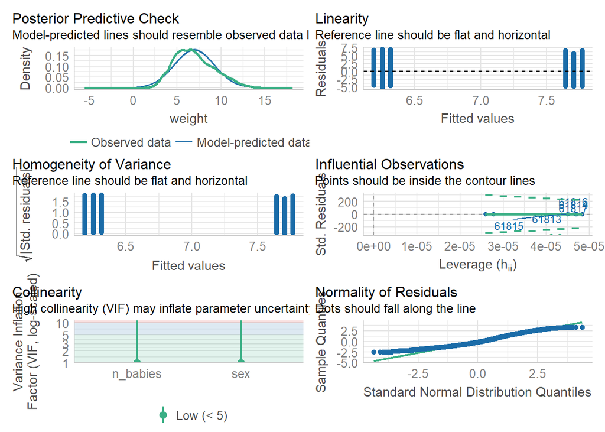

```r
library("performance")

check_model(mod3_3)
```